# DS605-HW12

George Cruz

4/25/2021

# Introduction to Data

The attached `who.csv` dataset contains real-world data from 2008. The variables included follow.

**Country:** name of the country  
**LifeExp:** average life expectancy for the country in years  
**InfantSurvival:** proportion of those surviving to one year or more  
**Under5Survival:** proportion of those surviving to five years or more  
**TBFree:** proportion of the population without TB.  
**PropMD:** proportion of the population who are MDs  
**PropRN:** proportion of the population who are RNs  
**PersExp:** mean personal expenditures on healthcare in US dollars at average exchange rate  
**GovtExp:** mean government expenditures per capita on healthcare, US dollars at average exchange rate  
**TotExp:** sum of personal and government expenditures.

```r
who <- read.csv("https://raw.githubusercontent.com/georg4re/DS605/main/data/who.csv")
summary(who)
```

```
##    Country             LifeExp      InfantSurvival   Under5Survival
##  Length:190         Min.   :40.00   Min.   :0.8350   Min.   :0.7310
##  Class :character   1st Qu.:61.25   1st Qu.:0.9433   1st Qu.:0.9253
##  Mode  :character   Median :70.00   Median :0.9785   Median :0.9745
##                     Mean   :67.38   Mean   :0.9624   Mean   :0.9459
##                     3rd Qu.:75.00   3rd Qu.:0.9910   3rd Qu.:0.9900
##                     Max.   :83.00   Max.   :0.9980   Max.   :0.9970
##      TBFree           PropMD              PropRN             PersExp
##  Min.   :0.9870   Min.   :0.0000196   Min.   :0.0000883   Min.   :   3.00
##  1st Qu.:0.9969   1st Qu.:0.0002444   1st Qu.:0.0008455   1st Qu.:  36.25
##  Median :0.9992   Median :0.0010474   Median :0.0027584   Median : 199.50
##  Mean   :0.9980   Mean   :0.0017954   Mean   :0.0041336   Mean   : 742.00
##  3rd Qu.:0.9998   3rd Qu.:0.0024584   3rd Qu.:0.0057164   3rd Qu.: 515.25
##  Max.   :1.0000   Max.   :0.0351290   Max.   :0.0708387   Max.   :6350.00
##     GovtExp             TotExp
##  Min.   :    10.0   Min.   :    13
##  1st Qu.:   559.5   1st Qu.:   584
##  Median :  5385.0   Median :  5541
##  Mean   : 40953.5   Mean   : 41696
##  3rd Qu.: 25680.2   3rd Qu.: 26331
##  Max.   :476420.0   Max.   :482750
```

# 1. ScatterPlot and Initial Linear Regression

Provide a scatterplot of LifeExp~TotExp, and run simple linear regression. Do not transform the variables. Provide and interpret the F statistics, R^2, standard error,and p-values only. Discuss whether the assumptions of simple linear regression met.

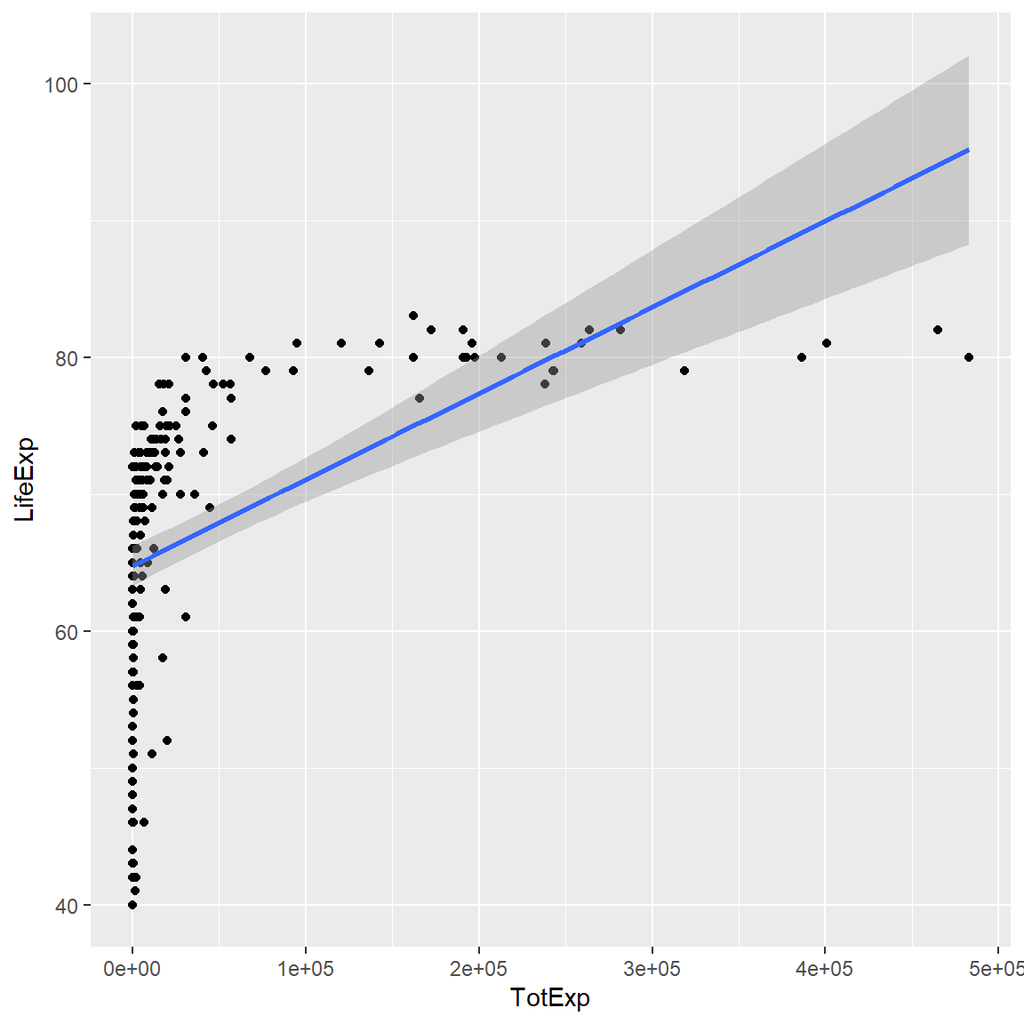

```r
ggplot(who, aes(x = TotExp, y = LifeExp)) +
  geom_point() +
  geom_smooth(method='lm', formula= y~x)
```

```r
le_te_lm <- lm(LifeExp ~ TotExp, data = who)
summary(le_te_lm)
```

```
##
## Call:
## lm(formula = LifeExp ~ TotExp, data = who)
##
## Residuals:
##     Min      1Q  Median      3Q     Max
## -24.764  -4.778   3.154   7.116  13.292
##
## Coefficients:
##              Estimate Std. Error t value Pr(>|t|)
## (Intercept) 6.475e+01  7.535e-01  85.933  < 2e-16 ***
## TotExp      6.297e-05  7.795e-06   8.079 7.71e-14 ***
## ---
## Signif. codes:  0 '***' 0.001 '**' 0.01 '*' 0.05 '.' 0.1 ' ' 1
##
## Residual standard error: 9.371 on 188 degrees of freedom
## Multiple R-squared:  0.2577, Adjusted R-squared:  0.2537
## F-statistic: 65.26 on 1 and 188 DF,  p-value: 7.714e-14
```

The `F-statistic` is *65.26* with a p-value close to 0 gives us an indication of a significant relationship between Total Expenditure and Life Expectancy.  
The $R^2$ tells us that this model accounts for only **25.77%** of the variation of the data.

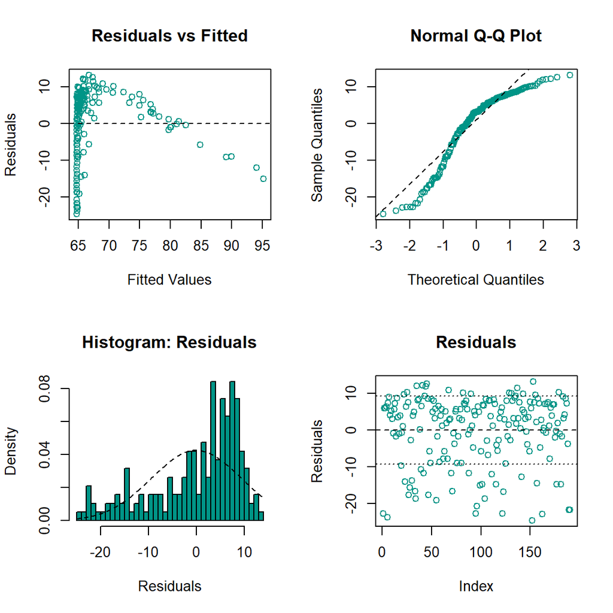

# 2. Which Model is Better?

Raise life expectancy to the 4.6 power (i.e., LifeExp^4.6).  
Raise total expenditures to the 0.06 power (nearly a log transform, TotExp^.06).

```r
who_2 <- who %>%
  mutate(TotExp = TotExp^0.06,
         LifeExp = LifeExp^4.6)
```

Plot LifeExp^4.6 as a function of TotExp^.06, and re-run the simple regression model using the transformed variables.

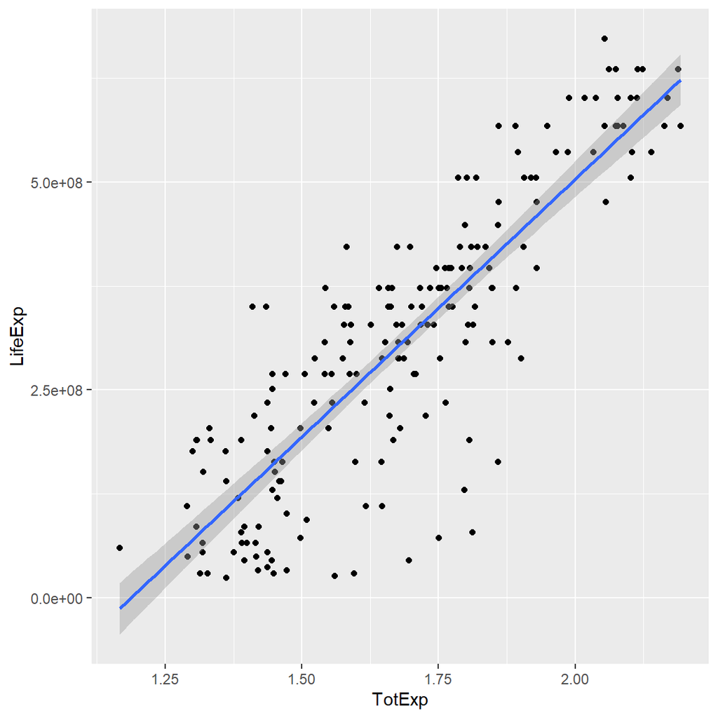

[output not shown]

[figure not shown]

```r
ggplot(who_2, aes(x = TotExp, y = LifeExp)) +
  geom_point() +
  geom_smooth(method='lm', formula= y~x)
```

**Provide and interpret the F statistics, R^2, standard error, and p-values.**

- **F Statistics & P-value:** the value is *507.7* with p-value very close to zero, which means there is significant evidence that the current model is better than the initial model. If we recall that the original model’s `F-statistic` was *65.26*, we can assume this is a better model.
- **$R^2$:** around 73% of the variability of the data can be explained by the current model vs 26% with the initial one.
- **Standard error:** the standard error is way larger than the initial model’s. Not entirely sure what that means

**Which model is “better?”**

The second model is a better one. It accounts for 73% of the variability. The distribution of the residuals is nearly normal and independent.

# 3. Forecast

Using the results from 3, forecast life expectancy when $TotExp^.06 =1.5$.

```r
at_1.5 <- (-736527910 + 620060216 * 1.5) ^ (1/4.6)

paste("Life Expectancy when Tot Exp = 1.5 is: ", at_1.5)
```

```
## [1] "Life Expectancy when Tot Exp = 1.5 is:  63.3115334478635"
```

Then forecast life expectancy when $TotExp^.06=2.5$

```r
at_2.5 <- (-736527910 + 620060216 * 2.5) ^ (1/4.6)

paste("Life Expectancy when Tot Exp = 2.5 is: ", at_2.5)
```

```
## [1] "Life Expectancy when Tot Exp = 2.5 is:  86.5064484928337"
```

# 4. Build Models.

Build the following multiple regression model and interpret the F Statistics, R^2, standard error, and p-values. How good is the model? $LifeExp = b_0+b_1 * PropMd + b_2 * TotExp + b_3 * PropMD * TotExp$

```r
model3 <- lm(LifeExp ~ PropMD + TotExp + PropMD*TotExp , who)
summary(model3)
```

```
##
## Call:
## lm(formula = LifeExp ~ PropMD + TotExp + PropMD * TotExp, data = who)
##
## Residuals:
##     Min      1Q  Median      3Q     Max
## -27.320  -4.132   2.098   6.540  13.074
##
## Coefficients:
##                 Estimate Std. Error t value Pr(>|t|)
## (Intercept)    6.277e+01  7.956e-01  78.899  < 2e-16 ***
## PropMD         1.497e+03  2.788e+02   5.371 2.32e-07 ***
## TotExp         7.233e-05  8.982e-06   8.053 9.39e-14 ***
## PropMD:TotExp -6.026e-03  1.472e-03  -4.093 6.35e-05 ***
## ---
## Signif. codes:  0 '***' 0.001 '**' 0.01 '*' 0.05 '.' 0.1 ' ' 1
##
## Residual standard error: 8.765 on 186 degrees of freedom
## Multiple R-squared:  0.3574, Adjusted R-squared:  0.3471
## F-statistic: 34.49 on 3 and 186 DF,  p-value: < 2.2e-16
```

- **F Statistics & P-value:** the value is *34.49* with p-value close to zero, the `F-statistic` is lower than the original model’s which was *65.26*.
- **$R^2$:** around 36% of the variability of the data can be explained by the current model vs 26% with the initial one.
- **Standard error:** the residual standard error is 8.765, smaller than the initial model’s.

Overall, this model seems better than the initial one but not as good as the transformed model.

# 5. Forecast LifeExp

when PropMD=.03 and TotExp = 14. Does this forecast seem realistic? Why or why not?

```r
62.77 + (1497 * 0.03) + (0.00007233 * 14) - (0.006026 * (0.03 * 14))
```

```
## [1] 107.6785
```

We saw that as the Total Expenditure increases, so does the life expectancy. That said, 107 appears to be a little high and unrealistic. Only two countries have a PropMD of 0.03 or higher and their TotExp are way higher than 14. The fact that these countries have LifeExp around 80 seem to imply that this proyection is totally unrealistic.